# Exercise #5 — Build the Spell Data, Then Model the Hazard (Answers)

PLSC 606J, Fall 2026

Author

Affiliation

Dave Clark

Binghamton University

Published

September 23, 2026

Answer key for Exercise #5. Part I is the construction and the checks against it; Part II is the polynomial comparison, which has a genuinely interesting answer; Part III is the hazard and the survivor function with simulated intervals, built step by step, and the same quantities with delta-method intervals alongside.

The regime measure here is Polity V. A V-Dem index is an equally good answer and will produce a slightly different estimation sample.

# Part I — Build the data

## 1. The construction

```r
archigos <- read_dta("https://www.rochester.edu/college/faculty/hgoemans/Archigos_4.1_stata14.dta") %>%
  mutate(startdate = as.Date(startdate),
         enddate   = as.Date(enddate),
         startyr   = as.numeric(format(startdate, "%Y")),
         endyr     = as.numeric(format(enddate,   "%Y")),
         spellyrs  = (endyr - startyr) + 1)            # calendar years the spell touches

# check spellyrs: the longest spell, and no zero or negative lengths
range(archigos$spellyrs)
```

```
[1]  1 69
```

```r
# expand: each spell's row repeated spellyrs times
leaderyears <- uncount(archigos, spellyrs)

# check: still 3,409 spells
n_distinct(leaderyears$obsid)
```

```
[1] 3409
```

```r
# year: the spell's first calendar year, then one more for each row after it
leaderyears <- leaderyears %>%
  group_by(obsid) %>%                                  # obsid = the SPELL, not the person
  mutate(year = startyr - 1 + row_number()) %>%
  ungroup()

# survival time, censoring, and failure
leaderyears <- leaderyears %>%
  arrange(obsid, year) %>%
  group_by(obsid) %>%
  mutate(t          = row_number(),                    # years in office so far
         censor     = if_else(exit == "Still in Office" & t == n(), 1, 0),
         leftoffice = if_else(censor == 0 & t == n(), 1, 0)) %>%
  ungroup()
```

These lines of code correspond to the three decisions:

`spellyrs = (endyr - startyr) + 1`, counted on calendar years, is the **partial-year** decision: a spell running November to February occupies two rows. The alternative — counting only whole years in office — is defensible, but would produce a different file. What is *not* defensible is failing to notice and make an explicit choice.

`group_by(obsid)` is the **spell** decision. `leadid` identifies the person, and 457 people held office more than once. Grouping by the person runs their separate spells together and counts the years they were out of power as time survived.

`exit == "Still in Office"`, in the `censor` line, is the **censoring** decision. Without it, every spell’s last row is a failure and the 165 leaders in power on 31 December 2015 and 3 still in power at the end of 2014 are recorded as having left. They had not; we stopped watching.

## 2. The checks

```r
tibble(
  Check = c("leader-years", "spells", "duplicate obsid-year", "rows at t == 1",
            "left office", "longest spell"),
  Target = c(17686, 3409, 0, 3409, 3241, 69),
  Got = c(nrow(leaderyears),
          n_distinct(leaderyears$obsid),
          sum(duplicated(paste(leaderyears$obsid, leaderyears$year))),
          sum(leaderyears$t == 1),
          sum(leaderyears$leftoffice),
          max(table(leaderyears$obsid)))
) %>%
  mutate(OK = if_else(Target == Got, "yes", "NO")) %>%
  kbl(caption = "The construction against its targets.") %>%
  kable_styling("striped", full_width = FALSE, font_size = 16)
```

The construction against its targets.

| Check | Target | Got | OK |
| --- | --- | --- | --- |
| leader-years | 17686 | 17686 | yes |
| spells | 3409 | 3409 | yes |
| duplicate obsid-year | 0 | 0 | yes |
| rows at t == 1 | 3409 | 3409 | yes |
| left office | 3241 | 3241 | yes |
| longest spell | 69 | 69 | yes |

**Why `rows at t == 1` is the check that earns its place.** The row and spell counts do not catch the `leadid` error, because grouping by the person produces exactly the same 17,686 rows — it changes the survival times, not the number of them. The count of first-years does catch it: every spell has one first year, so the target is the number of spells. Group by the person instead and you get the number of *people*.

```r
wrong <- leaderyears %>% arrange(leadid, year) %>%
  group_by(leadid) %>% mutate(t_wrong = row_number()) %>% ungroup()

c(rows_at_t1_correct = sum(leaderyears$t == 1),
  rows_at_t1_by_leader = sum(wrong$t_wrong == 1),
  survival_times_differing = sum(wrong$t_wrong != wrong$t),
  worst_overstatement = max(wrong$t_wrong - wrong$t))
```

```
      rows_at_t1_correct     rows_at_t1_by_leader survival_times_differing
                    3409                     2802                     2329
     worst_overstatement
                      24
```

2,329 survival times differ, and one is overstated by 24 years. Nothing about the resulting file looks wrong, which is exactly why the check has to be a number and not a glance.

## 3. The three decisions

Thinking of a choice, an alternative, and a consequence:

| decision | taken here | alternative | consequence |
| --- | --- | --- | --- |
| spell identity | `obsid` | `leadid` | 2,329 wrong survival times; time out of office counted as survived |
| partial years | calendar-year rows | whole years only | fewer rows, and short spells lose their exit year |
| censoring | still-in-office spells get 0 | code every last row 1 | 168 manufactured failures, concentrated in 2015 and among long-serving leaders |

## 4. The reflection

Reflect.

# Part II — Three baseline hazards

```r
polity <- read_csv(here("data", "p5v2018.csv"), show_col_types = FALSE) %>%
  dplyr::select(ccode, year, polity2)

before <- nrow(leaderyears)                            # rows before the join

leaderyears <- leaderyears %>%
  left_join(polity, by = c("ccode", "year"), relationship = "many-to-one")

c(before = before, after = nrow(leaderyears))          # unchanged: 17,686
```

```
before  after
 17686  17686
```

```r
leaderyears <- leaderyears %>%
  mutate(t2     = t^2,                                 # the baseline hazard's
         t3     = t^3,                                 #   polynomial terms
         age    = if_else(yrborn > 0, year - yrborn, NA_real_),   # yrborn is -999 when unknown
         female = as.integer(gender == "F"),
         entry  = factor(na_if(entry, "Unknown"),
                         levels = c("Regular", "Irregular", "Foreign Imposition")),
         region = case_when(ccode < 200 ~ "Americas",
                            ccode < 400 ~ "Europe",
                            ccode < 630 ~ "Africa",           # 600-629 is North Africa
                            ccode < 700 ~ "Middle East",
                            .default    = "Asia/Oceania"),
         region = factor(region, levels = c("Europe", "Americas", "Africa",
                                            "Middle East", "Asia/Oceania")))

# check: every region label matched a level, so the conversion created no NAs
sum(is.na(leaderyears$region))
```

```
[1] 0
```

```r
table(leaderyears$entry, useNA = "ifany")
```

```
           Regular          Irregular Foreign Imposition               <NA>
             14094               3304                285                  3
```

```r
mvars <- c("polity2", "age", "female", "entry", "region")

# the rows the model will drop, and what each one is missing
leaderyears %>%
  filter(if_any(all_of(mvars), is.na)) %>%
  mutate(missing_on = pmap_chr(across(all_of(mvars), is.na),
                               ~ paste(mvars[c(...)], collapse = " + "))) %>%
  count(missing_on, name = "leader_years", sort = TRUE)
```

```
# A tibble: 5 × 2
  missing_on      leader_years
  <chr>                  <int>
1 polity2                 1556
2 polity2 + age             45
3 age                       14
4 entry                      2
5 polity2 + entry            1
```

```r
est <- leaderyears %>% drop_na(all_of(mvars))

c(rows = nrow(leaderyears), estimation_sample = nrow(est),
  lost = nrow(leaderyears) - nrow(est))
```

```
             rows estimation_sample              lost
            17686             16068              1618
```

```r
m0 <- glm(leftoffice ~                  polity2 + age + female + entry + region,
          data = est, family = binomial(link = "logit"))
m1 <- glm(leftoffice ~ t +              polity2 + age + female + entry + region,
          data = est, family = binomial(link = "logit"))
m2 <- glm(leftoffice ~ t + t2 +         polity2 + age + female + entry + region,
          data = est, family = binomial(link = "logit"))
m3 <- glm(leftoffice ~ t + t2 + t3 +    polity2 + age + female + entry + region,
          data = est, family = binomial(link = "logit"))
```

## 5. The table

|  | no time | t | t, t² | t, t², t³ |
| --- | --- | --- | --- | --- |
| (Intercept) | -2.291*** | -2.350*** | -2.268*** | -2.352*** |
|  | (0.114) | (0.115) | (0.117) | (0.120) |
| Polity | 0.054*** | 0.041*** | 0.040*** | 0.039*** |
|  | (0.004) | (0.004) | (0.004) | (0.004) |
| Leader age | 0.016*** | 0.022*** | 0.022*** | 0.022*** |
|  | (0.002) | (0.002) | (0.002) | (0.002) |
| Female | -0.332* | -0.327* | -0.322* | -0.326* |
|  | (0.152) | (0.152) | (0.152) | (0.152) |
| Irregular entry | 0.394*** | 0.408*** | 0.403*** | 0.411*** |
|  | (0.061) | (0.061) | (0.061) | (0.062) |
| Foreign imposition | -0.028 | 0.034 | 0.049 | 0.068 |
|  | (0.225) | (0.226) | (0.226) | (0.227) |
| Survival time |  | -0.039*** | -0.071*** | -0.030+ |
|  |  | (0.004) | (0.008) | (0.016) |
| Survival time² |  |  | 0.001*** | -0.002* |
|  |  |  | (0.000) | (0.001) |
| Survival time³ |  |  |  | 0.000** |
|  |  |  |  | (0.000) |
| Num.Obs. | 16068 | 16068 | 16068 | 16068 |
| Log.Lik. | -7371.138 | -7316.134 | -7307.008 | -7302.034 |
| AIC | 14762.3 | 14654.3 | 14638.0 | 14630.1 |
| BIC | 14839.1 | 14738.8 | 14730.2 | 14730.0 |

+ p < 0.1, * p < 0.05, ** p < 0.01, *** p < 0.001  
Regional fixed effects estimated, not shown. Baseline: Europe.

## 6. Comparing fit

Two tools, doing two different jobs. These models are **nested** — each adds one term to the last — so a likelihood-ratio test applies: $-2(\ln L_{\text{restricted}} - \ln L_{\text{full}})$, distributed $\chi^2$ with degrees of freedom equal to the number of added parameters.

```r
lr <- function(a, b, lab) {
  x <- anova(a, b, test = "LRT")
  tibble(comparison = lab, LR = round(x$Deviance[2], 2), df = x$Df[2],
         p = format.pval(x$`Pr(>Chi)`[2], digits = 3))
}
bind_rows(lr(m0, m1, "no time -> t"),
          lr(m1, m2, "t -> t, t²"),
          lr(m2, m3, "t, t² -> t, t², t³")) %>%
  kbl(caption = "Likelihood-ratio tests, each step against the one before.") %>%
  kable_styling("striped", full_width = FALSE, font_size = 16)
```

Likelihood-ratio tests, each step against the one before.

| comparison | LR | df | p |
| --- | --- | --- | --- |
| no time -> t | 110.01 | 1 | <2e-16 |
| t -> t, t² | 18.25 | 1 | 1.94e-05 |
| t, t² -> t, t², t³ | 9.95 | 1 | 0.00161 |

```r
tibble(model = c("no time", "t", "t, t²", "t, t², t³"),
       k = map_dbl(list(m0, m1, m2, m3), ~ length(coef(.x))),
       logLik = map_dbl(list(m0, m1, m2, m3), ~ as.numeric(logLik(.x))),
       AIC = map_dbl(list(m0, m1, m2, m3), AIC),
       BIC = map_dbl(list(m0, m1, m2, m3), BIC)) %>%
  mutate(across(logLik:BIC, ~ round(.x, 1))) %>%
  kbl(caption = "Information criteria. AIC penalizes each parameter by 2; BIC by log(n) = 9.68.") %>%
  kable_styling("striped", full_width = FALSE, font_size = 16)
```

Information criteria. AIC penalizes each parameter by 2; BIC by log(n) = 9.68.

| model | k | logLik | AIC | BIC |
| --- | --- | --- | --- | --- |
| no time | 10 | -7371.1 | 14762.3 | 14839.1 |
| t | 11 | -7316.1 | 14654.3 | 14738.8 |
| t, t² | 12 | -7307.0 | 14638.0 | 14730.2 |
| t, t², t³ | 13 | -7302.0 | 14630.1 | 14730.0 |

**What each is doing.** The likelihood-ratio test asks a hypothesis question: *is the added coefficient different from zero?* With $n = 16{,}068$ it will answer yes to very small improvements, because it does not penalize parameters at all. The information criteria ask a different question — *which model would predict best out of sample?* — and they penalize for additinoal parameters: AIC charges 2 per parameter, BIC charges $\log(16{,}068) = 9.68$.

**Do they agree? Mostly, and where they part is the interesting bit.** Every LR step is significant, including the cubic ($\chi^2 = 9.95$, $p = 0.0016$). AIC picks the cubic outright, 14630.1 against 14638.0. **BIC cannot separate the quadratic from the cubic: 14730.2 against 14730.0, a gap of 0.26** — nothing at all on any of the usual scales. BIC’s stiffer penalty eats almost the whole gain from the third term.

## 7. Which model to keep

Both answers are defensible.

**For the cubic:** the LR test and AIC both endorse it, the $t^3$ coefficient is individually significant, and the cost of one extra parameter on 16,068 observations is trivial. If the baseline hazard’s shape is the object of interest — and in a hazard model it usually is — you want the flexibility.

**For the quadratic:** BIC says the third term buys 0.2, which is nothing, and a term that survives only the most permissive of three criteria is a thin reed. The quadratic already permits a non-monotonic baseline, which is the substantive requirement.

What I do not want is “the cubic, because $p < 0.05$.” Significance on 16,000 observations is cheap, and the whole point of putting AIC and BIC next to the LR test is to see them disagree and have to choose. I use the cubic from here on, though the quadratic would give visually indistinguishable figures — which is itself the strongest argument that the choice does not much matter. I prefer the cubic because it is more general in the sense that it relaxes the one-inflection point assumption.

## 8. Leader age across the four models

```r
tibble(model = c("no time", "t", "t, t²", "t, t², t³"),
       age = map_dbl(list(m0, m1, m2, m3), ~ coef(.x)["age"]),
       polity = map_dbl(list(m0, m1, m2, m3), ~ coef(.x)["polity2"])) %>%
  mutate(across(age:polity, ~ round(.x, 4))) %>%
  kbl(caption = "Two covariates as the baseline hazard is freed.") %>%
  kable_styling("striped", full_width = FALSE, font_size = 16)
```

Two covariates as the baseline hazard is freed.

| model | age | polity |
| --- | --- | --- |
| no time | 0.0159 | 0.0540 |
| t | 0.0217 | 0.0407 |
| t, t² | 0.0219 | 0.0397 |
| t, t², t³ | 0.0221 | 0.0389 |

The age coefficient climbs from 0.0159 to 0.0221, about 38%, and the answer is that **it is not about age.** Leaders age while they hold office: survival time and leader age are mechanically correlated. In a model with no measure of survival, age is the only variable available to absorb duration dependence, and it does so quietly, and with the wrong label on it insofar as we think of it as age, but it’s also measuring survival. Adding the survival baseline allows age to measure its independent effect explicitly.

Polity moves the other way, 0.054 to 0.039, for the same reason in reverse: some of what looked like a democracy effect was the composition of long and short spells.

The general lesson: **whenever a covariate is mechanically related to time in the spell, leaving the baseline hazard unmodeled loads that covariate with work it should not be doing.** This is a very specific kind of omitted-variable bias.

# Part III — Predictions

The question asks for average effects. I’m going to use this space to build average effects step-by-step, and then use those as sandboxes to generate delta standard errors, then to do it again and develop simulated measures of uncertainty (intervals).

I’ll start with average effects and build up in scale. I’ll generate the average effect for one leader-year, then for three, then all for the sample 16,068; then I’ll compute all of them at each of 25 years of tenure, then all of that at three values of Polity. In several cases, I build quantities twice - once as an explicit loop so we can see the process, then again in a more compact form — with a check that the two agree. The loop shows the process; the compact form is what you would write once the process is familiar.

## The build

### Step 1 — The three pieces

A predicted probability needs the coefficients and a row of data. An interval around it needs the covariance matrix as well.

```r
b <- coef(m3)                     # k coefficients, a named vector
V <- vcov(m3)                     # k x k covariance matrix
k <- length(b)
n <- nobs(m3)

c(cases = n, coefficients = k)
```

```
       cases coefficients
       16068           13
```

### Step 2 — The counterfactual design matrix

“Average effects” means: change the variable of interest for *every* case, leave each case’s own age, gender, route to power and region alone, predict, and average. So the first step is a copy of the data with the variables of interest overwritten. `est_cf5` is the estimation sample, counterfactual version: every row of `est`, with `polity2` and the spell clock overwritten and every other column left exactly as that leader-year had it. Same rows, same $n$. The clock is three columns — `t`, `t2`, and `t3` — and all three have to change together.

`model.matrix()` then turns that data frame into the numeric matrix `glm` actually used: factors become dummy columns, one per non-reference category.

```r
est_cf5 <- est %>% mutate(polity2 = 0, t = 5, t2 = 5^2, t3 = 5^3)   # Polity 0, year 5

# formula(m3)[-2] drops the left-hand side, because no outcome variable is needed
X5 <- model.matrix(formula(m3)[-2], data = est_cf5)

dim(X5)                           # n rows, k columns
```

```
[1] 16068    13
```

#### Step 2a — Reading the square brackets

`X5` has two dimensions, so it takes two indices separated by a comma. Leaving a slot empty means “all of them”:

| `X5[j, 4]` | row $j$, column 4 | one number |
| --- | --- | --- |
| `X5[j, ]` | row $j$, every column | a vector of length $k$ — one case |
| `X5[, 4]` | every row, column 4 | a vector of length $n$ — one variable |

The comma is what tells R the object is two-dimensional. Without it, R treats the matrix as one long vector running *down* the columns, which is legal and almost never what you meant.

```r
length(X5[1, ])            # k -- one case, all its variables
```

```
[1] 13
```

```r
length(X5[, 1])            # n -- one variable, all the cases
```

```
[1] 16068
```

```r
X5[2]                      # no comma: element 2 counting down column 1 -- not row 2
```

```
[1] 1
```

```r
X5[2, 1]                   # the same element, with both indices written out
```

```
[1] 1
```

```r
is.matrix(X5[1, ])         # a single row comes back as a plain vector
```

```
[1] FALSE
```

`X5[j, ]` comes back as a plain vector, not a one-row matrix. That is why `sum(X5[j, ] * b)` works below, and why `t(g) %*% V %*% g` works for the standard error.

### Step 3 — One case

Let’s choose one row - Margaret Thatcher’s fifth year in office is 1983; the UK’s actual Polity score that year is 10, and `est_cf5` has set it to 0.

```r
i <- which(est$leader == "Thatcher" & est$t == 5)

est[i, c("leader", "idacr", "year", "t", "age", "female", "entry", "region", "polity2")]
```

```
# A tibble: 1 × 9
  leader   idacr  year     t   age female entry   region polity2
  <chr>    <chr> <dbl> <int> <dbl>  <int> <fct>   <fct>    <dbl>
1 Thatcher UKG    1983     5    58      1 Regular Europe      10
```

```r
# her row of the design matrix, term by term
tibble(term = colnames(X5), x = X5[i, ], b = b, contribution = X5[i, ] * b)
```

```
# A tibble: 13 × 4
   term                        x          b contribution
   <chr>                   <dbl>      <dbl>        <dbl>
 1 (Intercept)                 1 -2.35          -2.35
 2 t                           5 -0.0300        -0.150
 3 t2                         25 -0.00221       -0.0552
 4 t3                        125  0.0000589      0.00736
 5 polity2                     0  0.0389         0
 6 age                        58  0.0221         1.28
 7 female                      1 -0.326         -0.326
 8 entryIrregular              0  0.411          0
 9 entryForeign Imposition     0  0.0677         0
10 regionAmericas              0 -0.125          0
11 regionAfrica                0 -0.760          0
12 regionMiddle East           0 -0.572          0
13 regionAsia/Oceania          0 -0.327          0
```

Two things to see in her row: `female` is 1, and all four region dummies are 0, because Europe is the reference category — there is no `regionEurope` column for it to occupy. The linear predictor is the last column added up, and the hazard is the logistic function of it.

```r
eta_i <- sum(X5[i, ] * b)                    # x_i'b -- one number
h_i   <- 1 / (1 + exp(-eta_i))               # same as plogis(eta_i)

c(eta = eta_i, h = h_i)
```

```
       eta          h
-1.5961082  0.1685262
```

The gradient is what the delta-method interval will need later: how $h_i$ moves when each coefficient moves. For the logit, $\partial h / \partial \eta = h(1-h)$, so by the chain rule the derivative with respect to coefficient $m$ is $h(1-h)$ times that case’s $x_m$.

```r
w_i <- h_i * (1 - h_i)                       # one number
g_i <- w_i * X5[i, ]                         # k numbers, one per coefficient

round(g_i, 5)
```

```
            (Intercept)                       t                      t2
                0.14013                 0.70063                 3.50313
                     t3                 polity2                     age
               17.51564                 0.00000                 8.12726
                 female          entryIrregular entryForeign Imposition
                0.14013                 0.00000                 0.00000
         regionAmericas            regionAfrica       regionMiddle East
                0.00000                 0.00000                 0.00000
     regionAsia/Oceania
                0.00000
```

### Step 4 — Three cases: what “average” is an average of

Three leader-years, all set to Polity 0 and year 5, differing only in the covariates they brought with them.

```r
three <- c(which(est$leader == "Thatcher" & est$t == 5),
           which(est$leader == "Mandela"  & est$t == 5),
           which(est$leader == "Nyerere"  & est$t == 5))

h_three <- numeric(3)
for (r in 1:3) {
  h_three[r] <- 1 / (1 + exp(-sum(X5[three[r], ] * b)))
}

tibble(leader = est$leader[three], year = est$year[three], age = est$age[three],
       region = est$region[three], h = round(h_three, 4))
```

```
# A tibble: 3 × 5
  leader    year   age region      h
  <chr>    <dbl> <dbl> <fct>   <dbl>
1 Thatcher  1983    58 Europe 0.168
2 Mandela   1998    80 Africa 0.176
3 Nyerere   1965    43 Africa 0.0862
```

```r
mean(h_three)              # the average hazard over these three cases
```

```
[1] 0.1435196
```

The next step does exactly this over all 16,068 rows instead of three.

### Step 5 — All cases: the average hazard and its gradient

One pass over the rows, accumulating two running totals: the hazards, and the gradients. Dividing each by $n$ at the end gives the average and its gradient.

```r
h_sum <- 0
g_sum <- rep(0, k)

for (j in 1:n) {
  eta_j <- sum(X5[j, ] * b)
  h_j   <- 1 / (1 + exp(-eta_j))
  w_j   <- h_j * (1 - h_j)

  h_sum <- h_sum + h_j
  g_sum <- g_sum + w_j * X5[j, ]              # add this case's k-vector to the total
}

hbar_loop <- h_sum / n
g_loop    <- g_sum / n
```

Here are the same two quantities without the loop. `X5 %*% b` does all $n$ linear predictors at once, and `colMeans` averages down the columns — that is, over cases.

```r
pr       <- plogis(as.vector(X5 %*% b))       # n hazards
hbar_vec <- mean(pr)
g_vec    <- colMeans((pr * (1 - pr)) * X5)    # each row scaled by its own w, then averaged

c(loop = hbar_loop, vectorized = hbar_vec)
```

```
      loop vectorized
 0.1833263  0.1833263
```

```r
all.equal(g_loop, g_vec)
```

```
[1] TRUE
```

Compare that to the three-case average: three cases average to 0.144, all 16,068 average to 0.183. The estimand is the second one.

The averaging runs over *cases*, at fixed coefficients. Averaging the $k$ columns instead would collapse the gradient to one number. Averaging over coefficient *draws* is a third thing, and that one is the simulation in Step 11.

### Step 6 — The standard error of that average

The delta method keeps the coefficients at `b` and uses calculus for the uncertainty: $\text{se} = \sqrt{g'\mathbf{V}g}$, with $g$ the gradient built in Step 5. Written out, that is a sum over every *pair* of coefficients — each pair’s covariance, weighted by both their gradients. With $k = 13$ there are 169 pairs.

```r
var_loop <- 0
for (r in 1:k) {
  for (cc in 1:k) {
    var_loop <- var_loop + g_loop[r] * V[r, cc] * g_loop[cc]
  }
}

var_matrix <- as.numeric(t(g_vec) %*% V %*% g_vec)     # the same 169 products

c(loop = sqrt(var_loop), matrix = sqrt(var_matrix))
```

```
loop.(Intercept)           matrix
     0.004200381      0.004200381
```

```r
# the interval, on the probability scale
hbar_vec + c(-1.96, 0, 1.96) * sqrt(var_matrix)
```

```
[1] 0.1750935 0.1833263 0.1915590
```

### Step 7 — Every year of tenure

Steps 2 through 6 did one year. Now do 25 of them, so the results need somewhere to live: two vectors of length 25, and a *matrix* with one row per year and one column per coefficient — because each year has a whole gradient, not a number.

```r
tmax <- 25                 # years of tenure to plot

hbar <- numeric(tmax)
se_h <- numeric(tmax)
G    <- matrix(NA, tmax, k)
colnames(G) <- names(b)

for (i in 1:tmax) {
  est_cf <- est %>% mutate(polity2 = 0, t = i, t2 = i^2, t3 = i^3)
  Xi <- model.matrix(formula(m3)[-2], data = est_cf)

  pr      <- plogis(as.vector(Xi %*% b))
  hbar[i] <- mean(pr)
  G[i, ]  <- colMeans((pr * (1 - pr)) * Xi)                  # write a k-vector into row i
  se_h[i] <- sqrt(as.numeric(t(G[i, ]) %*% V %*% G[i, ]))    # read row i back out
}

dim(G)                     # 25 x k
```

```
[1] 25 13
```

```r
length(G[3, ])             # k -- year 3's gradient, all coefficients
```

```
[1] 13
```

```r
length(G[, 3])             # 25 -- coefficient 3's gradient, all years
```

```
[1] 25
```

```r
head(tibble(t = 1:tmax, h = hbar, se = se_h,
            lo = hbar - 1.96 * se_h, hi = hbar + 1.96 * se_h))
```

```
# A tibble: 6 × 5
      t     h      se    lo    hi
  <int> <dbl>   <dbl> <dbl> <dbl>
1     1 0.209 0.00587 0.197 0.220
2     2 0.203 0.00460 0.194 0.212
3     3 0.197 0.00401 0.189 0.205
4     4 0.190 0.00396 0.182 0.198
5     5 0.183 0.00420 0.175 0.192
6     6 0.176 0.00451 0.167 0.185
```

### Step 8 — The survivor function: a running product and a running sum

Surviving to $t$ means not failing in year 1, *and* not failing in year 2, *and* so on. Each of those is a conditional probability, so they multiply:

$$S(t) = \prod_{j \le t}\left\{1 - \bar h(j)\right\}$$

$1 - \bar h(j)$ is the chance of getting through year $j$ having reached it, and the running product is the chance of getting through all of them. The $\bar h(j)$ are the average hazards from Step 7 — nothing new is estimated here.

The delta method needs the gradient of that product. Every $\bar h(j)$ in it is a function of the same $\beta$, so the gradient *adds* one term per year, with $g(j)$ the gradient of $\bar h(j)$ from Step 7:

$$\frac{\partial S(t)}{\partial \beta} = -S(t) \sum_{j \leq t} \frac{g(j)}{1 - \bar h(j)}$$

The two accumulators below run side by side — one multiplying, one adding — on the Polity 0 hazards and gradients from Step 7.

```r
S    <- numeric(tmax)
se_S <- numeric(tmax)

running_S <- 1                       # the product so far
running_q <- rep(0, k)               # the summed gradient so far, a k-vector

for (i in 1:tmax) {
  running_S <- running_S * (1 - hbar[i])
  running_q <- running_q + G[i, ] / (1 - hbar[i])

  S[i]    <- running_S
  se_S[i] <- running_S * sqrt(as.numeric(t(running_q) %*% V %*% running_q))
}
```

`cumprod` and `cumsum` are those two accumulators, written compactly.

```r
S_vec    <- cumprod(1 - hbar)
Q        <- apply(G / (1 - hbar), 2, cumsum)      # 25 x k: row i is running_q at year i
se_S_vec <- S_vec * sqrt(rowSums((Q %*% V) * Q))  # sqrt(q'Vq) for all 25 rows at once

c(all.equal(S, S_vec), all.equal(se_S, se_S_vec))
```

```
[1] TRUE TRUE
```

What the running sum is for: here is the same calculation with the 25 years treated as independent of each other, which is what dropping it amounts to. At $t = 1$ the two agree, because there is only one term to accumulate.

```r
se_S_wrong <- numeric(tmax)
for (i in 1:tmax) {
  se_S_wrong[i] <- sqrt(sum((S[i] / (1 - hbar[1:i]))^2 * se_h[1:i]^2))
}

tibble(t = 1:tmax, S = round(S, 3),
       se_correct = round(se_S, 4), se_independent = round(se_S_wrong, 4)) %>%
  filter(t %in% c(1, 5, 10, 25))
```

```
# A tibble: 4 × 4
      t     S se_correct se_independent
  <int> <dbl>      <dbl>          <dbl>
1     1 0.791     0.0059         0.0059
2     5 0.335     0.0083         0.0043
3    10 0.138     0.0062         0.0025
4    25 0.027     0.0029         0.0008
```

### Step 9 — The full grid: the delta method end to end

This step stands on its own. Every setting it uses is re-declared here, and Steps 2 through 8 are its body: build the counterfactual design matrix, average the predictions over cases, average the gradients, accumulate the product for $S(t)$. Nothing new happens below — it is the same work inside one more loop.

```r
b     <- coef(m3)                  # k coefficients
V     <- vcov(m3)                  # k x k covariance matrix
k     <- length(b)
tmax  <- 25                        # years of tenure to plot
pvals <- c(-10, 0, 10)             # the three counterfactual Polity values

qi <- tibble()                     # results pile up here, one block per Polity value

for (p in pvals) {

  # the hazard at each year: Steps 2, 5, 6 and 7, inside one loop
  hbar <- numeric(tmax)            # average hazard, one per year
  se_h <- numeric(tmax)            # its standard error
  G    <- matrix(NA, tmax, k)      # its gradient: one ROW per year, one column per coefficient

  for (i in 1:tmax) {
    est_cf <- est %>% mutate(polity2 = p, t = i, t2 = i^2, t3 = i^3)   # the counterfactual
    Xi <- model.matrix(formula(m3)[-2], data = est_cf)                 # n x k

    pr      <- plogis(as.vector(Xi %*% b))        # n predicted hazards
    hbar[i] <- mean(pr)                           # averaged over CASES
    G[i, ]  <- colMeans((pr * (1 - pr)) * Xi)     # each row scaled by its own w, then averaged
    se_h[i] <- sqrt(as.numeric(t(G[i, ]) %*% V %*% G[i, ]))        # sqrt(g'Vg)
  }

  # the survivor function: Step 8
  S    <- numeric(tmax)
  se_S <- numeric(tmax)

  running_S <- 1                   # the product so far
  running_q <- rep(0, k)           # the summed gradient so far

  for (i in 1:tmax) {
    running_S <- running_S * (1 - hbar[i])
    running_q <- running_q + G[i, ] / (1 - hbar[i])

    S[i]    <- running_S
    se_S[i] <- running_S * sqrt(as.numeric(t(running_q) %*% V %*% running_q))
  }

  qi <- bind_rows(qi, tibble(polity = p, t = 1:tmax,
                             h = hbar, h_se = se_h, s = S, s_se = se_S))
}

qi <- qi %>%
  mutate(h_lo = h - 1.96 * h_se, h_hi = h + 1.96 * h_se,
         s_lo = s - 1.96 * s_se, s_hi = s + 1.96 * s_se,
         polity = factor(polity, levels = pvals,
                         labels = c("Polity -10", "Polity 0", "Polity +10")))

qi
```

```
# A tibble: 75 × 10
   polity         t     h    h_se     s    s_se   h_lo  h_hi  s_lo  s_hi
   <fct>      <int> <dbl>   <dbl> <dbl>   <dbl>  <dbl> <dbl> <dbl> <dbl>
 1 Polity -10     1 0.153 0.00790 0.847 0.00790 0.137  0.168 0.832 0.863
 2 Polity -10     2 0.148 0.00715 0.722 0.0127  0.134  0.162 0.697 0.746
 3 Polity -10     3 0.143 0.00669 0.618 0.0156  0.130  0.157 0.588 0.649
 4 Polity -10     4 0.138 0.00643 0.533 0.0172  0.126  0.151 0.499 0.566
 5 Polity -10     5 0.133 0.00626 0.462 0.0180  0.121  0.145 0.427 0.497
 6 Polity -10     6 0.127 0.00614 0.403 0.0183  0.115  0.139 0.367 0.439
 7 Polity -10     7 0.122 0.00601 0.354 0.0182  0.110  0.134 0.318 0.390
 8 Polity -10     8 0.116 0.00586 0.313 0.0179  0.105  0.128 0.278 0.348
 9 Polity -10     9 0.111 0.00568 0.278 0.0175  0.0999 0.122 0.244 0.312
10 Polity -10    10 0.106 0.00548 0.249 0.0170  0.0949 0.116 0.215 0.282
# ℹ 65 more rows
```

### Step 10 — The two figures

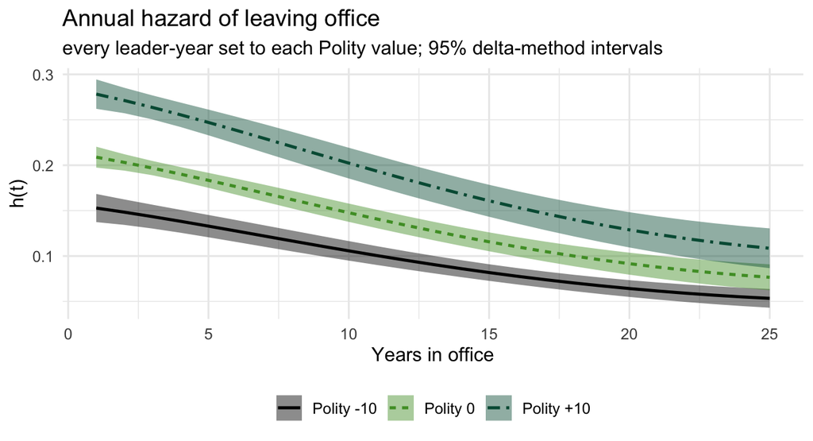

Figure 1

```r
ggplot(qi, aes(t, h, color = polity, fill = polity, linetype = polity)) +
  geom_ribbon(aes(ymin = h_lo, ymax = h_hi), alpha = 0.45, color = NA) +
  geom_line(linewidth = 0.9) +
  scale_color_manual(values = c(bu_black, bu_lightgreen, bu_green)) +
  scale_fill_manual(values = c(bu_black, bu_lightgreen, bu_green)) +
  scale_linetype_manual(values = bu_lty[1:3]) +
  labs(title = "Annual hazard of leaving office",
       subtitle = "every leader-year set to each Polity value; 95% delta-method intervals",
       x = "Years in office", y = "h(t)",
       color = NULL, fill = NULL, linetype = NULL) +   # linetype = NULL, or ggplot draws two legends
  theme_bu() + theme(legend.position = "bottom")
```

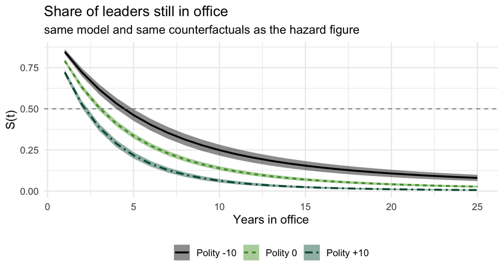

Figure 2

```r
ggplot(qi, aes(t, s, color = polity, fill = polity, linetype = polity)) +
  geom_ribbon(aes(ymin = s_lo, ymax = s_hi), alpha = 0.45, color = NA) +
  geom_line(linewidth = 0.9) +
  geom_hline(yintercept = 0.5, color = bu_grey, linetype = "dashed", linewidth = 0.4) +
  scale_color_manual(values = c(bu_black, bu_lightgreen, bu_green)) +
  scale_fill_manual(values = c(bu_black, bu_lightgreen, bu_green)) +
  scale_linetype_manual(values = bu_lty[1:3]) +
  labs(title = "Share of leaders still in office",
       subtitle = "same model and same counterfactuals as the hazard figure",
       x = "Years in office", y = "S(t)",
       color = NULL, fill = NULL, linetype = NULL) +
  theme_bu() + theme(legend.position = "bottom")
```

### Step 11 — The same quantities by simulation

This step stands on its own too. Every setting it uses is re-declared, so it can be read, or run, without Steps 2 through 10 in front of you.

```r
b      <- coef(m3)                 # k coefficients
V      <- vcov(m3)                 # k x k covariance matrix
k      <- length(b)
tmax   <- 25                       # years of tenure to plot
pvals  <- c(-10, 0, 10)            # the three counterfactual Polity values
ndraws <- 1000                     # coefficient vectors to draw

# the counterfactual design matrix at Polity 0 and year 5, rebuilt: every case
# as it would look under that counterfactual, its own covariates untouched
est_cf5_sim <- est %>% mutate(polity2 = 0, t = 5, t2 = 5^2, t3 = 5^3)
X5_sim      <- model.matrix(formula(m3)[-2], data = est_cf5_sim)

dim(X5_sim)                        # n cases x k coefficients
```

```
[1] 16068    13
```

#### Step 11a — What a draw is

Steps 2 through 10 held the coefficients fixed at `b` and used calculus for the uncertainty. Simulation holds nothing fixed: it draws 1,000 plausible coefficient vectors from the model’s own sampling distribution, $N(\widehat\beta, \mathbf{V})$, and recomputes the whole quantity once per draw. One draw is one row of `sims` — a complete alternative set of coefficients, near `b` and correlated the way `V` says they are.

```r
set.seed(20260916)   # fix the seed right before the draws, so anything run or printed
                     # earlier cannot shift them
sims <- MASS::mvrnorm(ndraws, b, V)      # ndraws rows, one draw each; k columns

dim(sims)
```

```
[1] 1000   13
```

```r
b_draw1 <- sims[1, ]
round(cbind(estimate = b, draw1 = b_draw1), 4)
```

```
                        estimate   draw1
(Intercept)              -2.3516 -2.1597
t                        -0.0300 -0.0401
t2                       -0.0022 -0.0018
t3                        0.0001  0.0001
polity2                   0.0389  0.0350
age                       0.0221  0.0212
female                   -0.3257 -0.3817
entryIrregular            0.4109  0.3579
entryForeign Imposition   0.0677  0.0688
regionAmericas           -0.1253 -0.2161
regionAfrica             -0.7596 -0.7438
regionMiddle East        -0.5722 -0.6439
regionAsia/Oceania       -0.3270 -0.3036
```

That draw’s average hazard is the Step 5 calculation with `b_draw1` in place of `b`: $n$ predictions, averaged over cases.

```r
mean(plogis(as.vector(X5_sim %*% b_draw1)))
```

```
[1] 0.1933044
```

#### Step 11b — All the draws at one year

Now every draw, still at Polity 0 and year 5. Each pass of the loop produces one number: an average over the $n$ cases, at that draw’s coefficients.

```r
h_draws_loop <- numeric(ndraws)
for (d in 1:ndraws) {
  h_draws_loop[d] <- mean(plogis(as.vector(X5_sim %*% sims[d, ])))
}
```

The compact form of that loop. `X5_sim %*% t(sims)` is an $n \times 1000$ matrix — one row per case, one column per draw — so each column holds $x_i\beta$ for every case under one draw’s coefficients. `plogis()` turns that into predicted probabilities, and `colMeans` averages down each column, over cases: one average prediction per draw.

```r
h_draws_vec <- colMeans(plogis(X5_sim %*% t(sims)))    # ndraws average hazards

all.equal(h_draws_loop, h_draws_vec)
```

```
[1] TRUE
```

`rowMeans` on that same matrix averages the other way, over draws within a case: $n$ numbers describing different leaders, not 1,000 describing estimation uncertainty. Both calls run; only one answers the question.

```r
length(colMeans(plogis(X5_sim %*% t(sims))))     # ndraws -- the sampling distribution
```

```
[1] 1000
```

```r
length(rowMeans(plogis(X5_sim %*% t(sims))))     # n      -- one number per leader-year
```

```
[1] 16068
```

The interval is the 2.5th and 97.5th percentiles of those 1,000 values.

```r
quantile(h_draws_vec, c(0.025, 0.5, 0.975))
```

```
     2.5%       50%     97.5%
0.1751696 0.1833743 0.1916925
```

#### Step 11c — The full grid

Every year of tenure from 1 to 25, at three values of Polity. Nothing new happens — it is the same work inside two more loops. For each Polity value, `hmat` holds years down the rows and draws across the columns. $S(t)$ is built *within* a draw — `cumprod` down one column at a time — so each draw’s survivor curve uses that draw’s own 25 hazards.

The interval at each year comes from the 1,000 values in that *row*. `apply(X, MARGIN, FUN)` runs a function over one dimension of a matrix: `X` is the matrix, `MARGIN` is the dimension (1 for rows, 2 for columns), and `FUN` is the function run along it — here the median and the two percentiles. `colMeans(M)` is the same thing as `apply(M, 2, mean)`.

```r
M <- matrix(1:6, nrow = 2)     # 2 x 3

apply(M, 1, sum)     # 9 12      -- 2 values, one per ROW    (rows kept)
```

```
[1]  9 12
```

```r
apply(M, 2, sum)     # 3 7 11    -- 3 values, one per COLUMN (columns kept)
```

```
[1]  3  7 11
```

Each draw also has its own median tenure — the first year its $S(t)$ drops below .5 — so median tenure gets an interval the same way: the 2.5th and 97.5th percentiles of 1,000 of them.

```r
first_below <- function(x) {             # the first year a survivor curve is below .5
  w <- which(x < 0.5)
  if (length(w)) w[1] else NA_integer_
}

sim_qi <- tibble()
tenure <- tibble()

for (p in pvals) {

  hmat <- matrix(NA, tmax, ndraws)         # years down the rows, draws across

  for (i in 1:tmax) {
    est_cf <- est %>% mutate(polity2 = p, t = i, t2 = i^2, t3 = i^3)
    Xi <- model.matrix(formula(m3)[-2], data = est_cf)
    hmat[i, ] <- colMeans(plogis(Xi %*% t(sims)))   # row i: this year, every draw
  }

  smat <- matrix(NA, tmax, ndraws)
  for (d in 1:ndraws) {
    smat[, d] <- cumprod(1 - hmat[, d])    # this draw's 25 hazards, chained
  }

  # intervals across the draws at each year: apply over ROWS
  sim_qi <- bind_rows(sim_qi,
    tibble(polity = p, t = 1:tmax,
           sim_h    = apply(hmat, 1, median),
           sim_h_lo = apply(hmat, 1, quantile, 0.025),
           sim_h_hi = apply(hmat, 1, quantile, 0.975),
           sim_s    = apply(smat, 1, median),
           sim_s_lo = apply(smat, 1, quantile, 0.025),
           sim_s_hi = apply(smat, 1, quantile, 0.975)))

  # one median tenure per draw: apply over COLUMNS
  med <- apply(smat, 2, first_below)
  tenure <- bind_rows(tenure, tibble(
    Polity                     = p,
    `Median tenure (yrs)`      = quantile(med, 0.5, type = 1, names = FALSE),
    `95% interval`             = sprintf("[%.0f, %.0f]", quantile(med, 0.025, type = 1),
                                                         quantile(med, 0.975, type = 1)),
    `Still in office at 5 yrs` = sprintf("%.0f%%", 100 * median(smat[5, ])),
    `at 10 yrs`                = sprintf("%.0f%%", 100 * median(smat[10, ]))))
}

sim_plot <- sim_qi %>%
  mutate(polity = factor(polity, levels = pvals,
                         labels = c("Polity -10", "Polity 0", "Polity +10")))
```

Same model, same counterfactuals as Step 10; the only difference is where the interval came from — percentiles of 1,000 draws here, $\sqrt{g'\mathbf{V}g}$ there. Side by side at Polity 0:

```r
left_join(sim_plot, qi, by = c("polity", "t")) %>%
  filter(polity == "Polity 0", t %in% c(1, 5, 10, 25)) %>%
  dplyr::select(t, sim_h, sim_h_lo, sim_h_hi, h, h_lo, h_hi) %>%
  mutate(across(-t, ~ round(.x, 3))) %>%
  kbl(caption = "The hazard at Polity 0: simulated (sim_) and delta-method intervals.") %>%
  kable_styling("striped", full_width = FALSE, font_size = 16)
```

The hazard at Polity 0: simulated (sim_) and delta-method intervals.

| t | sim_h | sim_h_lo | sim_h_hi | h | h_lo | h_hi |
| --- | --- | --- | --- | --- | --- | --- |
| 1 | 0.209 | 0.198 | 0.221 | 0.209 | 0.197 | 0.220 |
| 5 | 0.183 | 0.175 | 0.192 | 0.183 | 0.175 | 0.192 |
| 10 | 0.148 | 0.137 | 0.158 | 0.148 | 0.138 | 0.158 |
| 25 | 0.076 | 0.063 | 0.093 | 0.077 | 0.062 | 0.091 |

The survivor function agrees just as closely — at Polity 0 and year 5 both methods give [0.319, 0.351] — so while the slides warn that a first-order Taylor expansion (which is what the delta method is) may approximate $S(t)$ poorly, in these data it does not.

## 9. The hazard across survival time

The answer uses the simulated quantities from Step 11.

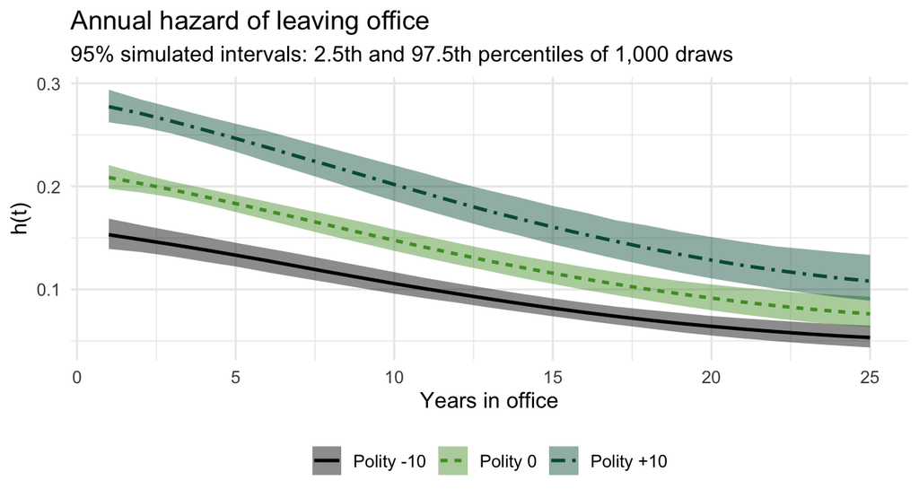

Figure 3

```r
ggplot(sim_plot, aes(t, sim_h, color = polity, fill = polity, linetype = polity)) +
  geom_ribbon(aes(ymin = sim_h_lo, ymax = sim_h_hi), alpha = 0.45, color = NA) +
  geom_line(linewidth = 0.9) +
  scale_color_manual(values = c(bu_black, bu_lightgreen, bu_green)) +
  scale_fill_manual(values = c(bu_black, bu_lightgreen, bu_green)) +
  scale_linetype_manual(values = bu_lty[1:3]) +
  labs(title = "Annual hazard of leaving office",
       subtitle = "95% simulated intervals: 2.5th and 97.5th percentiles of 1,000 draws",
       x = "Years in office", y = "h(t)",
       color = NULL, fill = NULL, linetype = NULL) +
  theme_bu() + theme(legend.position = "bottom")
```

Read as an article would: the annual risk of losing office is higher in democracies at every point in a leader’s tenure — 0.28 against 0.15 in the first year — and it declines slowly in both, so a leader who has already survived a decade faces a lower risk than a newcomer but nothing like safety.

The bands are worth a comment. They separate cleanly out to about twenty years and begin to overlap after that — the first adjacent overlap is at $t = 24$. That is not a failure of the model; it is the estimation sample thinning out. Very few leaders survive two decades, so there is little information about the hazard there, and the intervals say so.

## 10. The survivor function, and median tenure

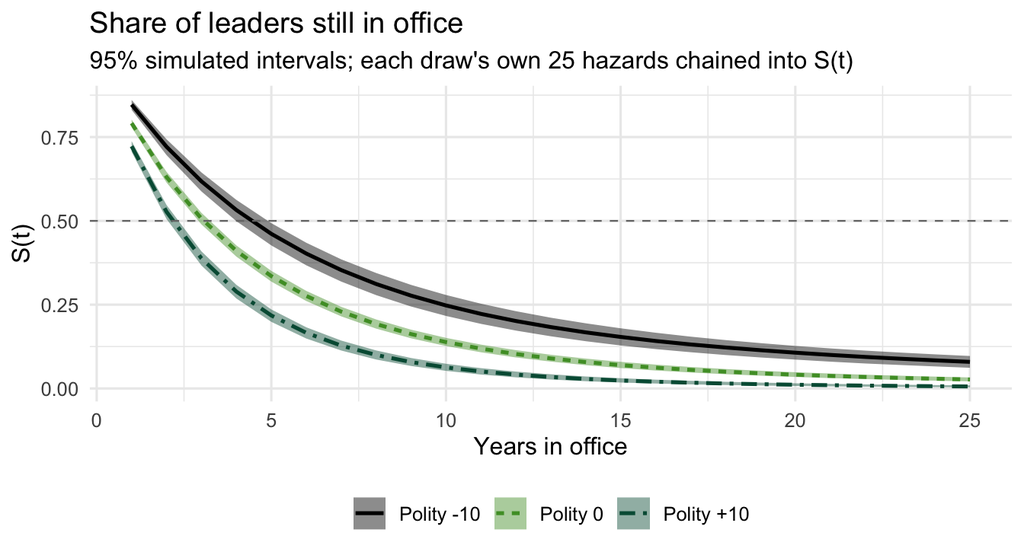

Figure 4

```r
ggplot(sim_plot, aes(t, sim_s, color = polity, fill = polity, linetype = polity)) +
  geom_ribbon(aes(ymin = sim_s_lo, ymax = sim_s_hi), alpha = 0.45, color = NA) +
  geom_line(linewidth = 0.9) +
  geom_hline(yintercept = 0.5, color = bu_grey, linetype = "dashed", linewidth = 0.4) +
  scale_color_manual(values = c(bu_black, bu_lightgreen, bu_green)) +
  scale_fill_manual(values = c(bu_black, bu_lightgreen, bu_green)) +
  scale_linetype_manual(values = bu_lty[1:3]) +
  labs(title = "Share of leaders still in office",
       subtitle = "95% simulated intervals; each draw's own 25 hazards chained into S(t)",
       x = "Years in office", y = "S(t)",
       color = NULL, fill = NULL, linetype = NULL) +
  theme_bu() + theme(legend.position = "bottom")
```

```r
tenure %>%
  kbl(caption = "Median time in office, and survival at five and ten years.") %>%
  kable_styling("striped", full_width = FALSE, font_size = 16)
```

Median time in office, and survival at five and ten years.

| Polity | Median tenure (yrs) | 95% interval | Still in office at 5 yrs | at 10 yrs |
| --- | --- | --- | --- | --- |
| -10 | 5 | [4, 5] | 46% | 25% |
| 0 | 4 | [3, 4] | 34% | 14% |
| 10 | 3 | [3, 3] | 22% | 6% |

Back to top